**Part 1:

**Data inspection**

#Load packages

```r
library("tidyverse")
library("dplyr")
library(data.table)
```

```r
library(ggplot2)
```

#Data Preparation #Read the data files (fang.mf and snp.mf) we are going to use.Because a header is present we will set the “header” argument to TRUE so that R knows the first line contains a header.

```r
fang.mf <- read.delim("C:/Users/mfakude/OneDrive - Iowa State University/Documents/EEOB546_R_lesson/fang_et_al_genotypes.txt", header = TRUE)
snp.mf <- read.delim ("C:/Users/mfakude/OneDrive - Iowa State University/Documents/EEOB546_R_lesson/snp_position.txt", header = TRUE)
```

#Data inspection of fang_et_al_genotypes.txt (Now named fang.mf)

```r
head(fang.mf) #shows first 6 rows
```

```
##   Sample_ID   JG_OTU Group abph1.20 abph1.22 ae1.3 ae1.4 ae1.5 an1.4 ba1.6
## 1     SL-15 T-aust-1 TRIPS      ?/?      ?/?   T/T   G/G   T/T   C/C   ?/?
## 2     SL-16 T-aust-2 TRIPS      ?/?      ?/?   T/T   ?/?   T/T   C/C   A/G
## 3     SL-11 T-brav-1 TRIPS      ?/?      ?/?   T/T   G/G   T/T   ?/?   G/G
## 4     SL-12 T-brav-2 TRIPS      ?/?      ?/?   T/T   G/G   T/T   C/C   G/G
## 5     SL-18   T-cund TRIPS      ?/?      ?/?   T/T   G/G   T/T   C/C   ?/?
## 6      SL-2 T-dact-1 TRIPS      ?/?      ?/?   T/T   G/G   T/T   C/C   A/G
##   ba1.9 bt2.5 bt2.7 bt2.8 Fea2.1 Fea2.5 id1.3 lg2.11 lg2.2 pbf1.1 pbf1.2 pbf1.3
## 1   G/G   ?/?   A/A   ?/?    C/C    A/A   T/T    C/C   A/A    ?/?    ?/?    ?/?
## 2   G/G   ?/?   A/A   ?/?    C/C    A/A   T/T    C/C   A/A    T/T    ?/?    ?/?
## 3   G/G   C/C   A/A   ?/?    ?/?    A/A   T/T    C/C   A/A    T/T    ?/?    ?/?
## 4   G/G   C/C   A/A   ?/?    ?/?    A/A   T/T    C/C   A/A    T/T    ?/?    ?/?
## 5   G/G   ?/?   A/A   ?/?    C/C    A/A   T/T    C/C   A/A    T/T    ?/?    ?/?
## 6   G/G   ?/?   A/A   ?/?    C/C    A/A   T/T    C/C   A/A    T/T    ?/?    ?/?
##   pbf1.5 pbf1.6 pbf1.7 pbf1.8 PZA00003.11 PZA00004.2 PZA00005.8 PZA00005.9
```

[output cut: 1021 more lines]

```r
tail(fang.mf) #shows last 6 rows
```

```
##      Sample_ID             JG_OTU Group abph1.20 abph1.22 ae1.3 ae1.4 ae1.5
## 2777    SYN262 Zmm-IL-W22-Rrstd_v ZMMIL      C/C      A/A   T/T   G/G   C/C
## 2778     S0398      Zmm-IL-W64A_a ZMMIL      G/G      A/A   T/T   G/G   C/C
## 2779     S1636    Zmm-IL-W64A_b_s ZMMIL      G/G      A/A   T/T   G/G   C/C
## 2780    CU0201        Zmm-IL-WD_f ZMMIL      C/C      A/A   T/T   G/G   C/C
## 2781     S0215         Zmm-IL-Wf9 ZMMIL      G/G      A/A   T/T   ?/?   C/C
## 2782    CU0202  Zmm-IL-Yu796_NS_f ZMMIL      C/C      A/A   T/T   G/G   C/C
##      an1.4 ba1.6 ba1.9 bt2.5 bt2.7 bt2.8 Fea2.1 Fea2.5 id1.3 lg2.11 lg2.2
## 2777   C/C   G/G   G/G   C/C   A/A   A/A    C/C    A/A   C/C    C/C   G/G
## 2778   C/C   G/G   G/G   C/C   G/G   A/A    ?/?    A/A   C/C    C/C   A/A
## 2779   C/C   G/G   G/G   C/C   G/G   A/A    G/G    A/A   C/C    C/C   A/A
## 2780   C/C   G/G   G/G   C/C   G/G   A/A    G/G    ?/?   C/C    C/C   G/G
## 2781   C/C   G/G   G/G   C/C   G/G   A/A    G/G    A/A   C/C    C/C   A/A
## 2782   C/C   ?/?   G/G   C/C   G/G   A/A    G/G    ?/?   ?/?    C/C   G/G
##      pbf1.1 pbf1.2 pbf1.3 pbf1.5 pbf1.6 pbf1.7 pbf1.8 PZA00003.11 PZA00004.2
```

[output cut: 1119 more lines]

```r
dim(fang.mf) #returns the dimensions of data frame (number of rows and number of columns)
```

```
## [1] 2782  986
```

```r
nrow(fang.mf) #number of rows
```

```
## [1] 2782
```

```r
ncol(fang.mf) #number of columns
```

```
## [1] 986
```

```r
str(fang.mf) #structure of data frame
```

```
## 'data.frame':    2782 obs. of  986 variables:
##  $ Sample_ID     : chr  "SL-15" "SL-16" "SL-11" "SL-12" ...
##  $ JG_OTU        : chr  "T-aust-1" "T-aust-2" "T-brav-1" "T-brav-2" ...
##  $ Group         : chr  "TRIPS" "TRIPS" "TRIPS" "TRIPS" ...
##  $ abph1.20      : chr  "?/?" "?/?" "?/?" "?/?" ...
##  $ abph1.22      : chr  "?/?" "?/?" "?/?" "?/?" ...
##  $ ae1.3         : chr  "T/T" "T/T" "T/T" "T/T" ...
##  $ ae1.4         : chr  "G/G" "?/?" "G/G" "G/G" ...
##  $ ae1.5         : chr  "T/T" "T/T" "T/T" "T/T" ...
##  $ an1.4         : chr  "C/C" "C/C" "?/?" "C/C" ...
##  $ ba1.6         : chr  "?/?" "A/G" "G/G" "G/G" ...
##  $ ba1.9         : chr  "G/G" "G/G" "G/G" "G/G" ...
##  $ bt2.5         : chr  "?/?" "?/?" "C/C" "C/C" ...
##  $ bt2.7         : chr  "A/A" "A/A" "A/A" "A/A" ...
##  $ bt2.8         : chr  "?/?" "?/?" "?/?" "?/?" ...
```

[output cut: 86 more lines]

```r
names(fang.mf) #shows the names attribute for a data frame, which gives the column names
```

```
##   [1] "Sample_ID"      "JG_OTU"         "Group"          "abph1.20"
##   [5] "abph1.22"       "ae1.3"          "ae1.4"          "ae1.5"
##   [9] "an1.4"          "ba1.6"          "ba1.9"          "bt2.5"
##  [13] "bt2.7"          "bt2.8"          "Fea2.1"         "Fea2.5"
##  [17] "id1.3"          "lg2.11"         "lg2.2"          "pbf1.1"
##  [21] "pbf1.2"         "pbf1.3"         "pbf1.5"         "pbf1.6"
##  [25] "pbf1.7"         "pbf1.8"         "PZA00003.11"    "PZA00004.2"
##  [29] "PZA00005.8"     "PZA00005.9"     "PZA00006.13"    "PZA00006.14"
##  [33] "PZA00008.1"     "PZA00010.5"     "PZA00013.10"    "PZA00013.11"
##  [37] "PZA00013.9"     "PZA00015.4"     "PZA00017.1"     "PZA00018.5"
##  [41] "PZA00029.11"    "PZA00029.12"    "PZA00030.11"    "PZA00031.5"
##  [45] "PZA00041.3"     "PZA00042.2"     "PZA00042.5"     "PZA00043.7"
##  [49] "PZA00045.1"     "PZA00047.2"     "PZA00049.12"    "PZA00050.9"
##  [53] "PZA00051.2"     "PZA00058.5"     "PZA00058.6"     "PZA00060.2"
##  [57] "PZA00061.1"     "PZA00065.2"     "PZA00069.4"     "PZA00070.5"
```

[output cut: 232 more lines]

```r
sapply(fang.mf, class) #shows the class of each column in the data frame
```

```
##      Sample_ID         JG_OTU          Group       abph1.20       abph1.22
##    "character"    "character"    "character"    "character"    "character"
##          ae1.3          ae1.4          ae1.5          an1.4          ba1.6
##    "character"    "character"    "character"    "character"    "character"
##          ba1.9          bt2.5          bt2.7          bt2.8         Fea2.1
##    "character"    "character"    "character"    "character"    "character"
##         Fea2.5          id1.3         lg2.11          lg2.2         pbf1.1
##    "character"    "character"    "character"    "character"    "character"
##         pbf1.2         pbf1.3         pbf1.5         pbf1.6         pbf1.7
##    "character"    "character"    "character"    "character"    "character"
##         pbf1.8    PZA00003.11     PZA00004.2     PZA00005.8     PZA00005.9
##    "character"    "character"    "character"    "character"    "character"
##    PZA00006.13    PZA00006.14     PZA00008.1     PZA00010.5    PZA00013.10
##    "character"    "character"    "character"    "character"    "character"
##    PZA00013.11     PZA00013.9     PZA00015.4     PZA00017.1     PZA00018.5
##    "character"    "character"    "character"    "character"    "character"
##    PZA00029.11    PZA00029.12    PZA00030.11     PZA00031.5     PZA00041.3
##    "character"    "character"    "character"    "character"    "character"
##     PZA00042.2     PZA00042.5     PZA00043.7     PZA00045.1     PZA00047.2
##    "character"    "character"    "character"    "character"    "character"
##    PZA00049.12     PZA00050.9     PZA00051.2     PZA00058.5     PZA00058.6
##    "character"    "character"    "character"    "character"    "character"
##     PZA00060.2     PZA00061.1     PZA00065.2     PZA00069.4     PZA00070.5
##    "character"    "character"    "character"    "character"    "character"
##     PZA00078.2     PZA00079.1    PZA00081.17     PZA00084.2     PZA00084.3
##    "character"    "character"    "character"    "character"    "character"
##     PZA00086.8     PZA00088.3     PZA00090.2     PZA00092.1     PZA00092.5
##    "character"    "character"    "character"    "character"    "character"
##     PZA00093.2    PZA00096.26    PZA00097.13    PZA00098.14    PZA00100.10
##    "character"    "character"    "character"    "character"    "character"
##    PZA00100.12    PZA00100.14     PZA00100.9    PZA00103.20     PZA00106.9
##    "character"    "character"    "character"    "character"    "character"
##    PZA00107.18    PZA00108.12    PZA00108.14    PZA00108.15     PZA00109.3
##    "character"    "character"    "character"    "character"    "character"
##     PZA00109.5     PZA00111.2     PZA00111.4     PZA00111.5     PZA00111.6
##    "character"    "character"    "character"    "character"    "character"
##     PZA00111.8     PZA00114.3     PZA00116.2     PZA00119.4     PZA00120.4
##    "character"    "character"    "character"    "character"    "character"
##     PZA00123.1     PZA00125.2    PZA00131.14    PZA00132.17    PZA00132.18
##    "character"    "character"    "character"    "character"    "character"
```

[output cut: 341 more lines]

```
##    "character"    "character"    "character"    "character"    "character"
##     PZD00077.5     PZD00077.7     PZD00077.8     PZD00078.2      Ra2_ORF.1
##    "character"    "character"    "character"    "character"    "character"
##      Ra2_ORF.2      Ra2_ORF.4 Ra2_promoter.1 Ra2_promoter.2 Ra2_promoter.3
##    "character"    "character"    "character"    "character"    "character"
##          sh2.5          sh2.6          sh2.7          sh2.9          su1.4
##    "character"    "character"    "character"    "character"    "character"
##          su1.5          su1.7         tb1.17         tb1.18         tb1.19
##    "character"    "character"    "character"    "character"    "character"
##          tb1.5          te1.3          te1.4        zagl1.1        zagl1.6
##    "character"    "character"    "character"    "character"    "character"
##         zap1.2         zen1.1         zen1.2         zen1.4         zfl2.6
##    "character"    "character"    "character"    "character"    "character"
##         zmm3.4
##    "character"
```

```r
ls(fang.mf)#shows objects in the objects in the frame
```

```
##   [1] "abph1.20"       "abph1.22"       "ae1.3"          "ae1.4"
##   [5] "ae1.5"          "an1.4"          "ba1.6"          "ba1.9"
##   [9] "bt2.5"          "bt2.7"          "bt2.8"          "Fea2.1"
##  [13] "Fea2.5"         "Group"          "id1.3"          "JG_OTU"
##  [17] "lg2.11"         "lg2.2"          "pbf1.1"         "pbf1.2"
##  [21] "pbf1.3"         "pbf1.5"         "pbf1.6"         "pbf1.7"
##  [25] "pbf1.8"         "PZA00003.11"    "PZA00004.2"     "PZA00005.8"
##  [29] "PZA00005.9"     "PZA00006.13"    "PZA00006.14"    "PZA00008.1"
##  [33] "PZA00010.5"     "PZA00013.10"    "PZA00013.11"    "PZA00013.9"
##  [37] "PZA00015.4"     "PZA00017.1"     "PZA00018.5"     "PZA00029.11"
##  [41] "PZA00029.12"    "PZA00030.11"    "PZA00031.5"     "PZA00041.3"
##  [45] "PZA00042.2"     "PZA00042.5"     "PZA00043.7"     "PZA00045.1"
##  [49] "PZA00047.2"     "PZA00049.12"    "PZA00050.9"     "PZA00051.2"
##  [53] "PZA00058.5"     "PZA00058.6"     "PZA00060.2"     "PZA00061.1"
##  [57] "PZA00065.2"     "PZA00069.4"     "PZA00070.5"     "PZA00078.2"
```

[output cut: 232 more lines]

##Data inspection of snp_position.txt (Now named snp.mf)

```r
head(snp.mf) #shows first 6 rows
```

```
##     SNP_ID cdv_marker_id Chromosome  Position alt_pos mult_positions amplicon
## 1 abph1.20          5976          2  27403404                           abph1
## 2 abph1.22          5978          2  27403892                           abph1
## 3    ae1.3          6605          5 167889790                             ae1
## 4    ae1.4          6606          5 167889682                             ae1
## 5    ae1.5          6607          5 167889821                             ae1
## 6    an1.4          5982          1 240498509                             an1
##   cdv_map_feature.name  gene candidate.random Genaissance_daa_id
## 1             AB042260 abph1        candidate               8393
## 2             AB042260 abph1        candidate               8394
## 3                  ae1   ae1        candidate               8395
## 4                  ae1   ae1        candidate               8396
## 5                  ae1   ae1        candidate               8397
## 6                  an1   an1        candidate               8398
##   Sequenom_daa_id count_amplicons count_cmf count_gene
## 1           10474               1         1          1
## 2           10475               0         0          0
## 3           10477               1         1          1
## 4           10478               0         0          0
## 5           10479               0         0          0
## 6           10481               1         1          1
```

```r
tail(snp.mf) #shows last 6 rows
```

```
##     SNP_ID cdv_marker_id Chromosome  Position alt_pos mult_positions amplicon
## 978 zap1.2          3514          2 233128584                            zap1
## 979 zen1.1          3519    unknown   unknown                            zen1
## 980 zen1.2          3520    unknown   unknown                            zen1
## 981 zen1.4          3521    unknown   unknown                            zen1
## 982 zfl2.6          6463          2  12543294                            zfl2
## 983 zmm3.4          3527          9  16966348                            zmm3
##     cdv_map_feature.name gene candidate.random Genaissance_daa_id
## 978               L46400 zap1        candidate               8434
## 979             CF649098 zen1        candidate               8435
## 980             CF649098 zen1        candidate               8436
## 981             CF649098 zen1        candidate               8437
## 982                 zfl2 zfl2        candidate               8438
## 983               Y09301 zmm3        candidate              10104
##     Sequenom_daa_id count_amplicons count_cmf count_gene
## 978           11823               1         0          1
## 979           11824               1         1          1
## 980           11826               0         0          0
## 981           11827               0         0          0
## 982           11828               1         1          1
## 983           11829               1         0          1
```

```r
dim(snp.mf) #returns the dimensions of data frame (number of rows and number of columns)
```

```
## [1] 983  15
```

```r
nrow(snp.mf) #number of rows
```

```
## [1] 983
```

```r
ncol(snp.mf) #number of columns
```

```
## [1] 15
```

```r
str(snp.mf) #structure of data frame - name, type and preview of data in each column
```

```
## 'data.frame':    983 obs. of  15 variables:
##  $ SNP_ID              : chr  "abph1.20" "abph1.22" "ae1.3" "ae1.4" ...
##  $ cdv_marker_id       : int  5976 5978 6605 6606 6607 5982 3463 3466 5983 5985 ...
##  $ Chromosome          : chr  "2" "2" "5" "5" ...
##  $ Position            : chr  "27403404" "27403892" "167889790" "167889682" ...
##  $ alt_pos             : chr  "" "" "" "" ...
##  $ mult_positions      : chr  "" "" "" "" ...
##  $ amplicon            : chr  "abph1" "abph1" "ae1" "ae1" ...
##  $ cdv_map_feature.name: chr  "AB042260" "AB042260" "ae1" "ae1" ...
##  $ gene                : chr  "abph1" "abph1" "ae1" "ae1" ...
##  $ candidate.random    : chr  "candidate" "candidate" "candidate" "candidate" ...
##  $ Genaissance_daa_id  : int  8393 8394 8395 8396 8397 8398 8399 8400 8401 8402 ...
##  $ Sequenom_daa_id     : int  10474 10475 10477 10478 10479 10481 10482 10483 10486 10487 ...
##  $ count_amplicons     : int  1 0 1 0 0 1 1 0 1 0 ...
##  $ count_cmf           : int  1 0 1 0 0 1 0 0 1 0 ...
##  $ count_gene          : int  1 0 1 0 0 1 1 0 1 0 ...
```

```r
names(snp.mf) #shows the names attribute for a data frame, which gives the column names
```

```
##  [1] "SNP_ID"               "cdv_marker_id"        "Chromosome"
##  [4] "Position"             "alt_pos"              "mult_positions"
##  [7] "amplicon"             "cdv_map_feature.name" "gene"
## [10] "candidate.random"     "Genaissance_daa_id"   "Sequenom_daa_id"
## [13] "count_amplicons"      "count_cmf"            "count_gene"
```

```r
sapply(snp.mf, class) #shows the class of each column in the data frame
```

```
##               SNP_ID        cdv_marker_id           Chromosome
##          "character"            "integer"          "character"
##             Position              alt_pos       mult_positions
##          "character"          "character"          "character"
##             amplicon cdv_map_feature.name                 gene
##          "character"          "character"          "character"
##     candidate.random   Genaissance_daa_id      Sequenom_daa_id
##          "character"            "integer"            "integer"
##      count_amplicons            count_cmf           count_gene
##            "integer"            "integer"            "integer"
```

```r
ls(fang.mf) #shows objects in the objects in the frame
```

```
##   [1] "abph1.20"       "abph1.22"       "ae1.3"          "ae1.4"
##   [5] "ae1.5"          "an1.4"          "ba1.6"          "ba1.9"
##   [9] "bt2.5"          "bt2.7"          "bt2.8"          "Fea2.1"
##  [13] "Fea2.5"         "Group"          "id1.3"          "JG_OTU"
##  [17] "lg2.11"         "lg2.2"          "pbf1.1"         "pbf1.2"
##  [21] "pbf1.3"         "pbf1.5"         "pbf1.6"         "pbf1.7"
##  [25] "pbf1.8"         "PZA00003.11"    "PZA00004.2"     "PZA00005.8"
##  [29] "PZA00005.9"     "PZA00006.13"    "PZA00006.14"    "PZA00008.1"
##  [33] "PZA00010.5"     "PZA00013.10"    "PZA00013.11"    "PZA00013.9"
##  [37] "PZA00015.4"     "PZA00017.1"     "PZA00018.5"     "PZA00029.11"
##  [41] "PZA00029.12"    "PZA00030.11"    "PZA00031.5"     "PZA00041.3"
##  [45] "PZA00042.2"     "PZA00042.5"     "PZA00043.7"     "PZA00045.1"
##  [49] "PZA00047.2"     "PZA00049.12"    "PZA00050.9"     "PZA00051.2"
##  [53] "PZA00058.5"     "PZA00058.6"     "PZA00060.2"     "PZA00061.1"
##  [57] "PZA00065.2"     "PZA00069.4"     "PZA00070.5"     "PZA00078.2"
```

[output cut: 232 more lines]

**Data Processing**

#Extract 3 columns (SNP_ID, Chromosome, Position) from snp.mf file and create a new file named snp_extracted. #Save the newly created file containg the extracted columns and view it in a spreadsheet-style. #Extract maize genotypes (ZMMIL, ZMMLR, ZMMMR) on ‘Group’ column from fang.mf file and create a new file named ‘maize’. #Save the newly created file containg the extracted maize and view it.

```r
snp_extracted <- snp.mf[,c("SNP_ID", "Chromosome", "Position")]
write.table(snp_extracted,"./Data_processing/snp_extracted.txt")
View(snp_extracted)
maize <- fang.mf %>% filter(Group == "ZMMIL" | Group == "ZMMLR" | Group == "ZMMMR")
write.table(maize,"./Data_processing/maize.txt")
```

#Extract teosinte genotypes (ZMPBA, ZMPIL, ZMPJA) on ‘Group’ column from fang.mf file and create a new file named ‘teosinte’. #Save the newly created file containg the extracted teosinte and view it.

```r
teosinte <- fang.mf %>% filter(Group == "ZMPBA" | Group == "ZMPIL" | Group == "ZMPJA")
write.table(teosinte,"./Data_processing/teosinte.txt")
```

##Join object maize file and with snp_extracted file (For Maize) #Transpose maize file #Save the transposed maize file #Name the first row SNP_ID #Join object maize file and with snp_extracted file #Save the joined maize file and view file

```r
maize_transposed <- t(maize[,-c(1:3)]) %>% as.data.frame()
write.table(maize_transposed,"./Data_processing/maize_transposed.txt")
maize_transposed$SNP_ID <- rownames(maize_transposed)
maize_final <- merge(snp_extracted,maize_transposed,by = 'SNP_ID')
colnames(maize_final)[4:ncol(maize_final)] <- as.character(maize$Sample_ID)
maize_final[,-c(1:3)] <- lapply(maize_final[,-c(1:3)],as.character)
unique(maize_final$Chromosome)
```

```
##  [1] "2"        "5"        "1"        "3"        "4"        "6"
##  [7] "9"        "8"        "multiple" "7"        "unknown"  "10"
```

```r
write.table(maize_final,"./Data_processing/maize_final.txt")
```

#Join object teosinte file and with snp_extracted file (For teosinte) #Transpose teosinte file #Save the transposed maize file #Name the first row SNP_ID #Join object teosinte file and with snp_extracted file #Save the joined teosinte file

```r
teosinte_transposed <- t(teosinte[,-c(1:3)]) %>% as.data.frame()
write.table(teosinte,"./Data_processing/teosinte_transposed.txt")
teosinte_transposed$SNP_ID <- rownames(teosinte_transposed)
teosinte_final <- merge(snp_extracted,teosinte_transposed,by = 'SNP_ID')
colnames(teosinte_final)[4:ncol(teosinte_final)]<-as.character(teosinte$Sample_I)
write.table(teosinte_final,"./Data_processing/teosinte_final.txt")
```

##Subseting maize/teosinte chromosomes with SNPs ordered based on increasing position values and with missing data encoded by this symbol: ?

##files with chromosomes with SNPs arranged on increasing position values and with missing data encoded by this symbol ‘?’ are name with an Q

##Files with chromosomes with SNPs arranged on decreasing position values and with missing data encoded by this symbol ‘-’ are name with an H. For example, maize_chr1_Q or maize_chr1_H/teosinte_chr1_Q or teosinte_chr1_H

```r
for (chr in 1:10){
  maize_chr <- subset(maize_final,Chromosome == chr) %>% arrange(Position)
  maize_chr[maize_chr == '?/?'] <- '?'
  write.table(maize_chr,file=paste("./Maize_chromosome/maize_chr",chr,"_Q.txt",sep = ""))
  maize_chr_d <- subset(maize_final,Chromosome == chr) %>% arrange(desc(Position))
  maize_chr_d[maize_chr_d == '?/?'] <- '-'
  write.table(maize_chr_d,file = paste("./Maize_chromosome/maize_chr",chr,"_H.txt",sep = ""))

  teosinte_chr <- subset(teosinte_final,Chromosome == chr) %>% arrange(Position)
  teosinte_chr[teosinte_chr == '?/?'] <- '?'
  write.table(teosinte_chr,file = paste("./Teosinte_chromosome/teosinte_chr",chr,"_Q.txt",sep = ""))
  teosinte_chr_d <- subset(teosinte_final,Chromosome == chr) %>% arrange(desc(Position))
  teosinte_chr_d[teosinte_chr_d == '?/?'] <- '-'
  write.table(teosinte_chr_d,file = paste("./Teosinte_chromosome/teosinte_chr",chr,"_H.txt",sep = ""))
}
```

**Part 2**

**Data visualization**

##1.(i) Plot SNPs per chromososome #Filter the original snp_position file by position and command to filter for items less than infinity #Pipe the filtering to produce a bar graph of total SNP counts per chromosome #Label the X-axis and the y-axis and save the plot

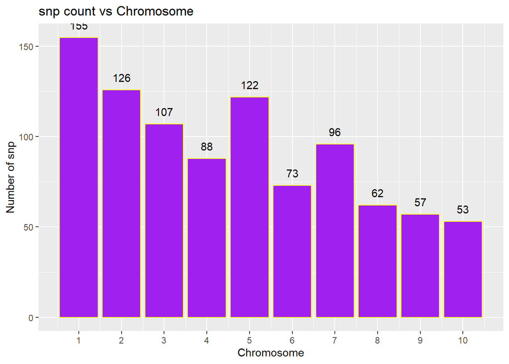

```r
library(ggplot2)
snp.mf %>%
  filter(Position < 10e1000) %>%
  ggplot(aes(as.double(Chromosome))) +
  geom_bar(fill = 'purple', color = 'yellow') +
  geom_text(stat = 'count', aes(label = ..count..), vjust = -1) +
  scale_x_continuous(breaks = 1:10) +
  theme_replace() +
  ggtitle("snp count vs Chromosome") +
  ylab('Number of snp') +
  xlab('Chromosome')
```

```r
ggsave("./Data_visualization/Number of snp_chromosome.png")
```

#1(ii)Plotting SNP distribution across the chromosome #Filter the position for anything less than infinity and map them to position per Mb #Pipe the latter to produce a histogram that show the distributionof SNPs in a chromosome  
#Color the histogram with a purple color #Plot each chromosome using facet wrap #Label the X-axis and the y-axis and save the plot

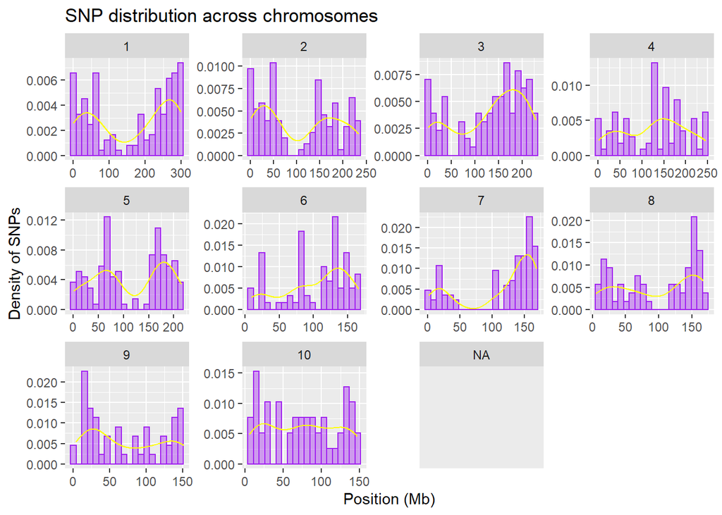

```r
snp.mf %>% filter(Position < 10e1000) %>%
  ggplot(aes(as.double(Position)/1000000)) +
  geom_histogram(aes(y = ..density..), color = 'purple', fill = "purple", alpha = 0.4, bins = 20) +
  geom_density(aes(as.double(Position)/1000000), color = "yellow") +
  facet_wrap(~ as.double(Chromosome), scales = "free") +
  theme_replace() +
  ggtitle("SNP distribution across chromosomes") +
  xlab('Position (Mb)') +
  ylab('Density of SNPs')
```

```r
ggsave("./Data_visualization/SNP_distribution_across_chromosomes.png")
```

##2 Missing data and amount of heterozygosity

##2(i) Proportion of homozygous and heterozygous by Sample ID #Remove the 2nd tha the 3rd column in fang.mf and pipe it pivot_long by Sample_ID, to produce a tibble of each SNP and its genotypic value #Mutate the file to add a colum with homozygous and heterozygous SNPs

#Plot graph (SNPs) by Sample ID and save it

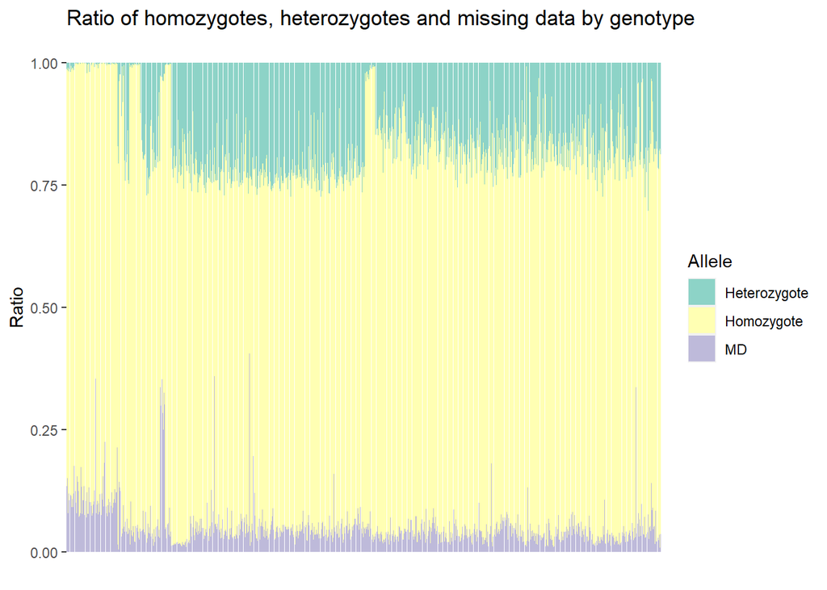

```r
mutate_Sampleid <-
  fang.mf %>% select(-JG_OTU, -Group) %>%
  pivot_longer(!Sample_ID) %>%
  mutate(Allele = ifelse(value %in% c('C/C', 'G/G', 'A/A', 'T/T'), 'Homozygote', ifelse(value == '?/?', 'MD', 'Heterozygote')))
View(mutate_Sampleid)

library(RColorBrewer)
color_plots <- brewer.pal(3, "Set3")
mutate_Sampleid %>% group_by(Sample_ID) %>%  count(Allele) %>%
  ggplot(aes(fill = Allele, y = n, x = Sample_ID)) +
  geom_bar(position = "fill", stat = "identity") +
  scale_fill_manual(values = color_plots) +
  ggtitle("Ratio of homozygotes, heterozygotes and missing data by genotype ") +
  ylab('Ratio') +
  theme(axis.title.x=element_blank(),
        axis.text.x=element_blank(),
        axis.ticks.x=element_blank())
```

```r
ggsave("./Data_visualization/Gene_ratio by sample.png")
```

#Plot graph (SNPs) by group and save it

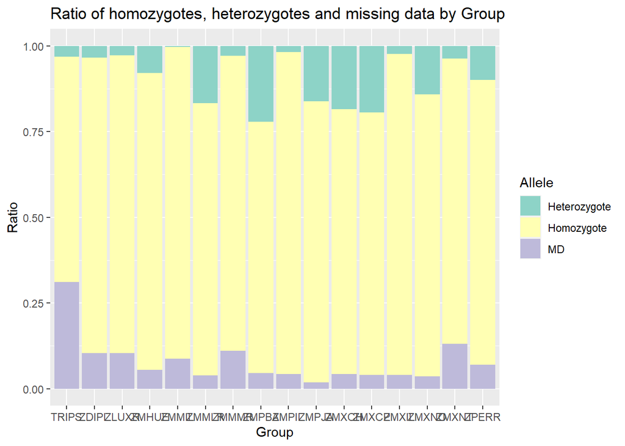

```r
mutate_Group <-
  fang.mf %>% select(-JG_OTU, -Sample_ID) %>%
  pivot_longer(!Group) %>%
  mutate(Allele = ifelse(value %in% c('C/C', 'G/G', 'A/A', 'T/T'), 'Homozygote', ifelse(value == '?/?', 'MD', 'Heterozygote')))
View(mutate_Group)

mutate_Group %>% group_by(Group) %>%  count(Allele) %>%
  ggplot(aes(fill = Allele, y = n, x = Group)) +
  geom_bar(position = "fill", stat = "identity") +
  scale_fill_manual(values = color_plots) +
  ggtitle("Ratio of homozygotes, heterozygotes and missing data by Group ") +
  ylab('Ratio')
```

```r
ggsave("./Data_visualization/Ratio of zygosity and missing data.png")
```

#3.My_plot_ Plot graph of proprotion of homozygotes by Group and save it

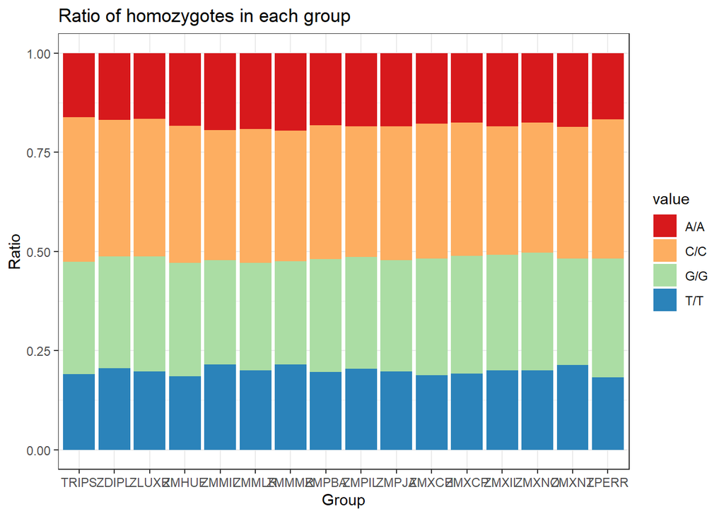

```r
color2 <- brewer.pal(4, "Spectral")
mutate_Group %>% filter(Allele == "Homozygote") %>% group_by(Group) %>%  count(value) %>%
  ggplot(aes(fill = value, y = n, x = Group)) +
  geom_bar(position = "fill", stat = "identity") +
  scale_fill_manual(values = color2) +
  ggtitle("Ratio of homozygotes in each group") +
  ylab('Ratio') +
  theme_bw()
```

```r
ggsave("./Data_visualization/my_plot.png")
```